# Spam Detection

Rohit Rajagopal

#### The following script utilises the SMS Spam Detection dataset from UCI to build various predictive models to categorise whether a message is spam or not.

```r
# Load required libraries
library(tidyverse)
library(rpart)
library(e1071)
library(ranger)
library(textstem)
library(tm)
library(ggplot2)
library(wordcloud)
set.seed(10)
```

### Data Loading

Read in CSV file and modify dataset as required. Data obtained from https://www.kaggle.com/datasets/uciml/sms-spam-collection-dataset.

```r
# Read in dataset
sms_data <- read_csv("spam.csv")
# Find dataset dimensions
cat("Shape of Spam Dataset:", paste(dim(sms_data), collapse = "x"), "\n")
```

```
Shape of Spam Dataset: 5572x5
```

```r
sms_data
```

| v1 | v2 | ...3 | ...4 | ...5 |
| --- | --- | --- | --- | --- |
| ham | Go until jurong point, crazy.. Available only in bugis n great world la e buffet... Cine there got amore wat... | NA | NA | NA |
| ham | Ok lar... Joking wif u oni... | NA | NA | NA |
| spam | Free entry in 2 a wkly comp to win FA Cup final tkts 21st May 2005. Text FA to 87121 to receive entry question(std txt rate)T&C's apply 08452810075over18's | NA | NA | NA |
| ham | U dun say so early hor... U c already then say... | NA | NA | NA |
| ham | Nah I don't think he goes to usf, he lives around here though | NA | NA | NA |
| spam | FreeMsg Hey there darling it's been 3 week's now and no word back! I'd like some fun you up for it still? Tb ok! XxX std chgs to send, \xe5\xa31.50 to rcv | NA | NA | NA |
| ham | Even my brother is not like to speak with me. They treat me like aids patent. | NA | NA | NA |
| ham | As per your request 'Melle Melle (Oru Minnaminunginte Nurungu Vettam)' has been set as your callertune for all Callers. Press *9 to copy your friends Callertune | NA | NA | NA |
| spam | WINNER!! As a valued network customer you have been selected to receivea \xe5\xa3900 prize reward! To claim call 09061701461. Claim code KL341. Valid 12 hours only. | NA | NA | NA |
| spam | Had your mobile 11 months or more? U R entitled to Update to the latest colour mobiles with camera for Free! Call The Mobile Update Co FREE on 08002986030 | NA | NA | NA |

[output cut: 990 more lines]

There seem to be a few blank columns, let’s check these don’t contain any values at all.

```r
# Count non-blank rows in each column using !is.na()
non_na_counts <- colSums(sapply(sms_data, function(x) !is.na(x)))
print(non_na_counts)
```

```
  v1   v2 ...3 ...4 ...5
5572 5572   50   12    6
```

All the columns contain non-NA values, therefore let’s concatenate columns 2 to 5 to form the entire message.

```r
# Create combined column and drop the remaining ones
sms_data$v2 <- paste(sms_data$v2,
                       ifelse(sms_data$...3 != "" & !is.na(sms_data$...3), sms_data$...3, ""),
                       ifelse(sms_data$...4 != "" & !is.na(sms_data$...4), sms_data$...4, ""),
                       ifelse(sms_data$...5 != "" & !is.na(sms_data$...5), sms_data$...5, ""),
                       sep = " ")
sms_data <- sms_data[, -c(3, 4, 5)]

# Rename remaining columns for readability
colnames(sms_data) <- c("spam_label", "text")
sms_data
```

| spam_label | text |
| --- | --- |
| ham | Go until jurong point, crazy.. Available only in bugis n great world la e buffet... Cine there got amore wat... |
| ham | Ok lar... Joking wif u oni... |
| spam | Free entry in 2 a wkly comp to win FA Cup final tkts 21st May 2005. Text FA to 87121 to receive entry question(std txt rate)T&C's apply 08452810075over18's |
| ham | U dun say so early hor... U c already then say... |
| ham | Nah I don't think he goes to usf, he lives around here though |
| spam | FreeMsg Hey there darling it's been 3 week's now and no word back! I'd like some fun you up for it still? Tb ok! XxX std chgs to send, \xe5\xa31.50 to rcv |
| ham | Even my brother is not like to speak with me. They treat me like aids patent. |
| ham | As per your request 'Melle Melle (Oru Minnaminunginte Nurungu Vettam)' has been set as your callertune for all Callers. Press *9 to copy your friends Callertune |
| spam | WINNER!! As a valued network customer you have been selected to receivea \xe5\xa3900 prize reward! To claim call 09061701461. Claim code KL341. Valid 12 hours only. |
| spam | Had your mobile 11 months or more? U R entitled to Update to the latest colour mobiles with camera for Free! Call The Mobile Update Co FREE on 08002986030 |

[output cut: 990 more lines]

### Data Visualisation

Let’s have a look at how the dataset is distributed.

```r
# Find number of spam and non-spam messages
counts <- table(sms_data$spam_label)
print(counts)
```

```
 ham spam
4825  747
```

Evidently, there are much more ham (non-spam) messages than spam in the dataset. This leads to extreme class imbalance and may affect the reliability of the models.

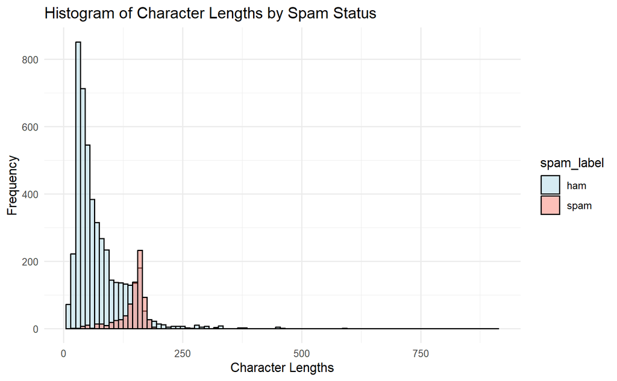

```r
# Check and convert text encoding UTF-8
sms_data$text <- iconv(sms_data$text, to = "UTF-8", sub = "byte")

# Find number of characters in text
char_lengths <- nchar(sms_data$text)

# Create a histogram of characters in each message
ggplot(sms_data, aes(x = char_lengths, fill = spam_label)) +
  geom_histogram(binwidth = 10, position = "identity", alpha = 0.5, color = "black") +
  labs(title = "Histogram of Character Lengths by Spam Status",
       x = "Character Lengths",
       y = "Frequency") +
  scale_fill_manual(values = c("lightblue", "salmon")) +
  theme_minimal()
```

```r
# Get summary stats
print(tapply(char_lengths, sms_data$spam_label, summary))
```

```
$ham
   Min. 1st Qu.  Median    Mean 3rd Qu.    Max.
   5.00   36.00   56.00   74.91   97.00  913.00

$spam
   Min. 1st Qu.  Median    Mean 3rd Qu.    Max.
   16.0   137.0   155.0   144.8   163.0   233.0
```

The plot above indicates that spam messages usually have more characters than ham, with a peak at around 150 compared to the latter at 25. The summary stats support this view.

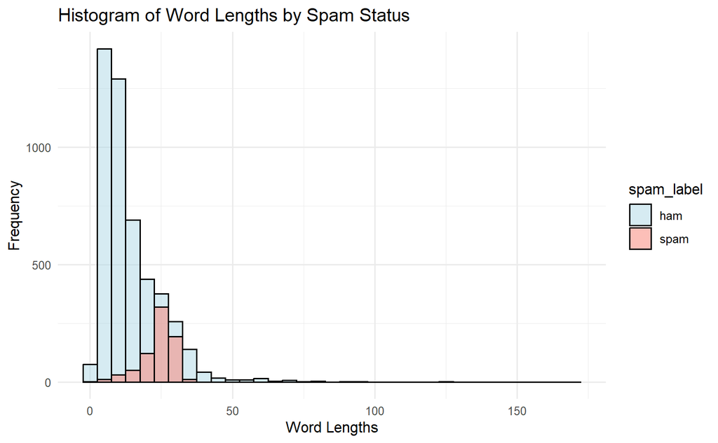

```r
# Find number of words in text
word_lengths <- str_count(sms_data$text, "\\S+")

# Create a histogram of words in each message
ggplot(sms_data, aes(x = word_lengths, fill = spam_label)) +
  geom_histogram(binwidth = 5, position = "identity", alpha = 0.5, color = "black") +
  labs(title = "Histogram of Word Lengths by Spam Status",
       x = "Word Lengths",
       y = "Frequency") +
  scale_fill_manual(values = c("lightblue", "salmon")) +
  theme_minimal()
```

```r
# Get summary stats
print(tapply(word_lengths, sms_data$spam_label, summary))
```

```
$ham
   Min. 1st Qu.  Median    Mean 3rd Qu.    Max.
   1.00    7.00   11.00   14.31   19.00  171.00

$spam
   Min. 1st Qu.  Median    Mean 3rd Qu.    Max.
   2.00   22.00   25.00   23.91   28.00   35.00
```

The plot above once again dictates that spam messages are likely to contain more words than their ham counterparts. The former has a mean of 24 compared to 14 for the latter.

```r
# Find whether each message contains numbers and if so, how many
has_numbers <- grepl("[[:digit:]]", sms_data$text)
number_count <- sapply(gregexpr("[[:digit:]]", sms_data$text), function(x) sum(x > 0))

# Split of spam and non-spam messages containing numbers
number_count_splits = table(sms_data$spam_label, has_numbers)
cat("\n")
```

```r
print(number_count_splits)
```

```
      has_numbers
       FALSE TRUE
  ham   4022  803
  spam    39  708
```

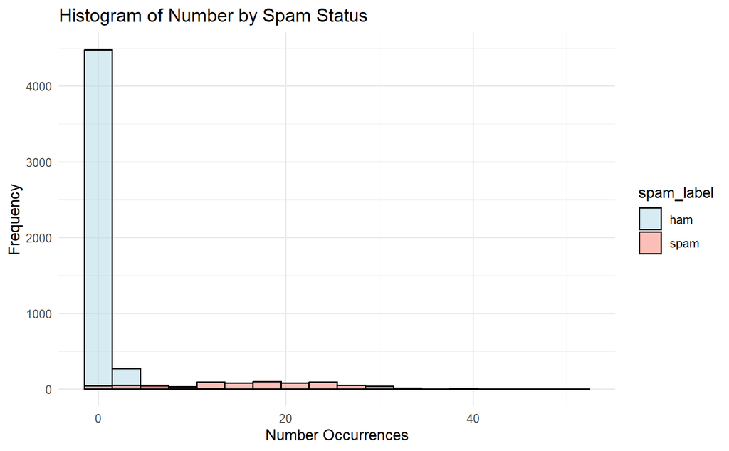

```r
# Create a histogram of the occurrences of numbers in each message
ggplot(sms_data, aes(x = number_count, fill = spam_label)) +
  geom_histogram(binwidth = 3, position = "identity", alpha = 0.5, color = "black") +
  labs(title = "Histogram of Number by Spam Status",
       x = "Number Occurrences",
       y = "Frequency") +
  scale_fill_manual(values = c("lightblue", "salmon")) +
  theme_minimal()
```

```r
# Get summary stats
print(tapply(has_numbers, sms_data$spam_label, summary))
```

```
$ham
   Mode   FALSE    TRUE
logical    4022     803

$spam
   Mode   FALSE    TRUE
logical      39     708
```

```r
print(tapply(number_count, sms_data$spam_label, summary))
```

```
$ham
   Min. 1st Qu.  Median    Mean 3rd Qu.    Max.
 0.0000  0.0000  0.0000  0.3662  0.0000 23.0000

$spam
   Min. 1st Qu.  Median    Mean 3rd Qu.    Max.
    0.0    11.0    17.0    16.7    23.0    51.0
```

Spam messages seem to contain more numbers than ham. This likely pertains to the fact that spam messages usually contain phone numbers to dial or strange links to click on.

```r
# Find whether each message contains non-alphanumeric characters and if so, how many
has_non_alphanum <- grepl("[^[:alnum:]]", sms_data$text)
non_alphanum_count <- sapply(gregexpr("[^[:alnum:]]", sms_data$text), function(x) sum(x > 0))

# Split of spam and non-spam messages containing non-alphanumeric characters
non_alphanum_count_splits = table(sms_data$spam_label, has_non_alphanum)
cat("\n")
```

```r
print(non_alphanum_count_splits)
```

```
      has_non_alphanum
       TRUE
  ham  4825
  spam  747
```

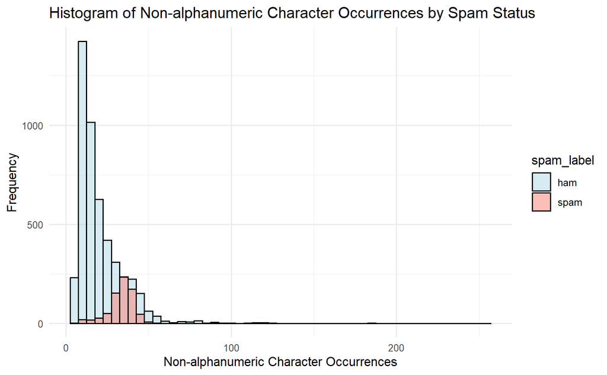

```r
# Create a histogram of the occurrences of non-alphanumeric characters in each message
ggplot(sms_data, aes(x = non_alphanum_count, fill = spam_label)) +
  geom_histogram(binwidth = 5, position = "identity", alpha = 0.5, color = "black") +
  labs(title = "Histogram of Non-alphanumeric Character Occurrences by Spam Status",
       x = "Non-alphanumeric Character Occurrences",
       y = "Frequency") +
  scale_fill_manual(values = c("lightblue", "salmon")) +
  theme_minimal()
```

```r
# Get summary stats
print(tapply(has_non_alphanum, sms_data$spam_label, summary))
```

```
$ham
   Mode    TRUE
logical    4825

$spam
   Mode    TRUE
logical     747
```

```r
print(tapply(non_alphanum_count, sms_data$spam_label, summary))
```

```
$ham
   Min. 1st Qu.  Median    Mean 3rd Qu.    Max.
   3.00   11.00   16.00   20.65   26.00  256.00

$spam
   Min. 1st Qu.  Median    Mean 3rd Qu.    Max.
   4.00   30.00   35.00   33.42   38.00   56.00
```

Finally, spam messages also have more non-alphanumeric characters (punctuation, emoticons etc.) than ham. All 4 plots above suggest there is a distinct separation between the two groups which may be useful for the model building process.

### Data Preprocessing

Clean and process text data using a standardised NLP approach (such as removing punctuation, stop words, and lemmatisation), such that the models can interpret each message correctly.

```r
# Create corpus of words
corpus <- Corpus(VectorSource(sms_data$text))

# Convert to lower case
corpus <- tm_map(corpus, content_transformer(tolower))
# Remove punctuation
corpus <- tm_map(corpus, content_transformer(str_replace_all), pattern = "[[:punct:]]", replacement = " ")
# Remove numbers
corpus <- tm_map(corpus, content_transformer(str_replace_all), pattern = "[[:digit:]]", replacement = " ")
# Remove stopwords
corpus <- tm_map(corpus, removeWords, stopwords("en"))
# Perform lemmatisation (reduce words to their canonical or dictionary form in English)
corpus <- tm_map(corpus, lemmatize_strings)
# Remove extra white spaces
corpus <- tm_map(corpus, content_transformer(str_replace_all), pattern = "\\s+", replacement = " ")
```

```r
# View first 10 messages in corpus to see cleaned output
for (i in 1:10) {
  line <- corpus[[i]][["content"]]
  cat(line, "\n")
}
```

```
go jurong point crazy available bugis n great world la e buffet cine get amore wat
okay lar joke wif u oni
free entry wkly comp win fa cup final tkts st may text fa receive entry question std txt rate t c s apply s
u dun say early hor u c already say
nah don t think go usf life around though
freemsg hey darling s week s now word back have like fun still tb okay xxx std chgs send <e >< > rcv
even brother like speak treat like aid patent
per request melle melle oru minnaminunginte nurungu vettam set callertune caller press copy friend callertune
winner value network customer select receivea <e >< > prize reward claim call claim code kl valid hour
mobile month u r entitle update late colour mobile camera free call mobile update co free
```

```r
# Create a Term-Document Matrix (TDM)
tdm <- DocumentTermMatrix(corpus)
tdm_matrix = as.matrix(tdm)
spam_matrix <- tdm_matrix[which(sms_data$spam_label == "spam"), ]
ham_matrix <- tdm_matrix[which(sms_data$spam_label == "ham"), ]

# Convert dtm to a matrix of word frequencies
word_freq <- colSums(tdm_matrix)
spam_freq <- colSums(spam_matrix)
ham_freq  <- colSums(ham_matrix)

# Generate word clouds for spam and non-spam messages
spam_messages <- head(spam_freq, 75)
par(mfrow = c(1, 1))
wordcloud(names(spam_messages), spam_messages, min.freq = 1, random.order = FALSE, colors = brewer.pal(8, "Dark2"))
title(main = "Word Cloud for Top 75 Words used in Spam Messages")
```

[figure not shown]

```r
ham_messages <- head(ham_freq, 75)
par(mfrow = c(1, 1))
```

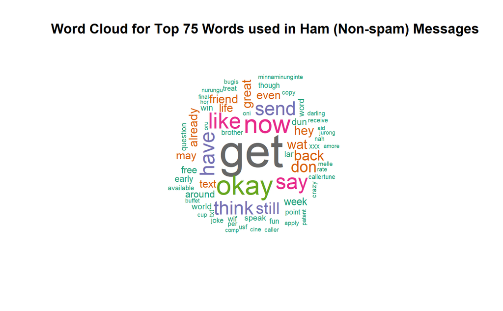

```r
wordcloud(names(ham_messages), ham_messages, min.freq = 1, random.order = FALSE, colors = brewer.pal(8, "Dark2"))
title(main = "Word Cloud for Top 75 Words used in Ham (Non-spam) Messages")
```

The word clouds above show that spam messages are likely to contain words such as “text”, “send”, “free”, and “now” as they usually involve a transfer of private information. Ham messages on the other hand, contain more conversational phrases as expected.

```r
# Convert TDM to Dataframe
tdm_df <- as.data.frame(tdm_matrix, stringsAsFactors = FALSE)

# Append on additional features such as character and word count, numbers, and non-alphanumeric characters
tdm_complete = cbind("spam_label" = as.factor(sms_data$spam_label), char_lengths, word_lengths, non_alphanum_count, number_count, tdm_df)

# Find matrix dimensions
cat("Shape of Feature Matrix:", paste(dim(tdm_complete), collapse = "x"), "\n")
```

```
Shape of Feature Matrix: 5572x6283
```